# Project_4_Bank_Churner_Full_code

## Data Preprocessing

### Train-validation-test Split

```python
X = df.drop(['Exited'],axis=1) # Credit Score through Estimated Salary
y = df['Exited'] # Exited
```

```python
# Splitting the dataset into the Training, validation and Testing set.

X_temp,X_test,y_temp,y_test=train_test_split(X,y,test_size=0.20,random_state=42, stratify=y,shuffle = True)

X_train,X_val,y_train,y_val=train_test_split(X_temp,y_temp,test_size=0.25,random_state=42, stratify=y_temp, shuffle = True)
print("X_train size is {}".format(X_train.shape))
print("X_val size is {}".format(X_val.shape))
print("X_test size is {}".format(X_test.shape))
print("y_train size is {}".format(y_train.shape))
print("y_val size is {}".format(y_val.shape))
print("y_test size is {}".format(y_test.shape))
```

```
X_train size is (6000, 10)
X_val size is (2000, 10)
X_test size is (2000, 10)
y_train size is (6000,)
y_val size is (2000,)
y_test size is (2000,)
```

### Data Normalization

Since all the numerical values are on a different scale, so we will be scaling all the numerical values to bring them to the same scale.

```python
from sklearn.preprocessing import StandardScaler
import pandas as pd

# Function to standardize data
def standardize_data(scaler, df, num_cols, cat_cols):
    num_subset = scaler.transform(df[num_cols])
    num_df = pd.DataFrame(num_subset, columns=num_cols)
    for col in cat_cols:
        num_df[col] = df[col].values
    return num_df

# Columns to be standardized and kept as is
num_cols = ['CreditScore', 'Age', 'Tenure', 'Balance', 'NumOfProducts', 'EstimatedSalary']
cat_cols = ['Geography', 'Gender', 'HasCrCard', 'IsActiveMember']

# StandardScaler
scaler = StandardScaler()

# Fit the scaler on the training data
scaler.fit(X_train[num_cols])

# Standardize train, validation, and test datasets
X_train = standardize_data(scaler, X_train, num_cols, cat_cols)
X_val = standardize_data(scaler, X_val, num_cols, cat_cols)
X_test = standardize_data(scaler, X_test, num_cols, cat_cols)

# Display the first few rows of the standardized training data
X_train.head()
```

|  | CreditScore | Age | Tenure | Balance | NumOfProducts | EstimatedSalary | Geography | Gender | HasCrCard | IsActiveMember |
| --- | --- | --- | --- | --- | --- | --- | --- | --- | --- | --- |
| 0 | -0.694374 | 0.480890 | -0.009572 | 0.295612 | 0.797297 | 0.124178 | France | Female | 1 | 1 |
| 1 | -2.049957 | -0.091560 | 1.022171 | 0.696248 | -0.913029 | 0.528050 | Germany | Female | 1 | 0 |
| 2 | 1.571829 | 0.385481 | -0.697401 | -1.240550 | -0.913029 | -0.478379 | Spain | Male | 1 | 0 |
| 3 | -0.518459 | 0.194665 | -0.697401 | -1.240550 | 0.797297 | -0.787547 | Spain | Female | 1 | 0 |
| 4 | -1.242816 | 0.290073 | 0.334342 | 0.177637 | 0.797297 | -0.422558 | Germany | Female | 1 | 0 |

```python
## Convert the categorical features to numerical
X_train=pd.get_dummies(X_train,columns=['Geography','Gender'], drop_first=True,dtype=float)
X_test=pd.get_dummies(X_test,columns=['Geography','Gender'], drop_first=True,dtype=float)
X_val=pd.get_dummies(X_val,columns=['Geography','Gender'], drop_first=True,dtype=float)
X_train.head()
```

|  | CreditScore | Age | Tenure | Balance | NumOfProducts | EstimatedSalary | HasCrCard | IsActiveMember | Geography_Germany | Geography_Spain | Gender_Male |
| --- | --- | --- | --- | --- | --- | --- | --- | --- | --- | --- | --- |
| 0 | -0.694374 | 0.480890 | -0.009572 | 0.295612 | 0.797297 | 0.124178 | 1 | 1 | 0.0 | 0.0 | 0.0 |
| 1 | -2.049957 | -0.091560 | 1.022171 | 0.696248 | -0.913029 | 0.528050 | 1 | 0 | 1.0 | 0.0 | 0.0 |
| 2 | 1.571829 | 0.385481 | -0.697401 | -1.240550 | -0.913029 | -0.478379 | 1 | 0 | 0.0 | 1.0 | 1.0 |
| 3 | -0.518459 | 0.194665 | -0.697401 | -1.240550 | 0.797297 | -0.787547 | 1 | 0 | 0.0 | 1.0 | 0.0 |
| 4 | -1.242816 | 0.290073 | 0.334342 | 0.177637 | 0.797297 | -0.422558 | 1 | 0 | 1.0 | 0.0 | 0.0 |

## Model Building

### Model Evaluation Criterion

For the task of customer churn prediction, we are choosing Recall as the primary metric because the cost of missing a churn prediction (false negative) is more significant than falsely predicting churn (false positive). Therefore, we will be selecting a model with high recall to ensure that most of the actual churned customers are identified.

**Let's create a function for plotting the confusion matrix**

```python
def make_confusion_matrix(actual_targets, predicted_targets):
    """
    To plot the confusion_matrix with percentages

    actual_targets: actual target (dependent) variable values
    predicted_targets: predicted target (dependent) variable values
    """
    cm = confusion_matrix(actual_targets, predicted_targets)
    labels = np.asarray(
        [
            ["{0:0.0f}".format(item) + "\n{0:.2%}".format(item / cm.flatten().sum())]
            for item in cm.flatten()
        ]
    ).reshape(cm.shape[0], cm.shape[1])

    plt.figure(figsize=(6, 4))
    sns.heatmap(cm, annot=labels, fmt="")
    plt.ylabel("True label")
    plt.xlabel("Predicted label")
```

For this analysis, we are going to train various Neural Network models and keep tracking of the recall values. In order to store the recall values from various models we are creating two dataframe that will store the recall values for all the models we build.

```python
# Initialize the DataFrame to store the recall values
metrics_df = pd.DataFrame(columns=["train_recall", "valid_recall", "recall_difference"])
```

### Neural Network with SGD Optimizer

```python
# Enable eager execution for more detailed error messages
tf.config.run_functions_eagerly(True)

# Clear the previous session
tf.keras.backend.clear_session()
```

```python
# backend.clear_session()
#Fixing the seed for random number generators so that we can ensure we receive the same output everytime
np.random.seed(2)
random.seed(2)
tf.random.set_seed(2)
```

```python
# Initializing the neural network
model_0 = Sequential()

# Adding the input layer with 64 neurons and relu as activation function
model_0.add(Dense(64, activation='relu', input_dim=X_train.shape[1]))

# Adding a hidden layer with 32 neurons and relu as activation function
model_0.add(Dense(32, activation='relu'))

# Adding the output layer with 1 neuron (for binary classification) and sigmoid activation function
model_0.add(Dense(1, activation='sigmoid'))
```

```python
# Compiling the model with binary cross entropy as loss function and recall as the metric
optimizer = SGD(learning_rate=0.001)
metric = 'Recall'
model_0.compile(loss='binary_crossentropy', optimizer=optimizer, metrics=[metric])
```

```python
# Check the shape of the dataset
print("X_train shape:", X_train.shape)
print("X_val shape:", X_val.shape)
print("X_test shape:", X_test.shape)

print("y_train shape:", y_train.shape)
print("y_val shape:", y_val.shape)
print("y_test shape:", y_test.shape)
```

```
X_train shape: (6000, 11)
X_val shape: (2000, 11)
X_test shape: (2000, 11)
y_train shape: (6000,)
y_val shape: (2000,)
y_test shape: (2000,)
```

```python
model_0.summary()
```

```
Model: "sequential"
```

```
┏━━━━━━━━━━━━━━━━━━━━━━━━━━━━━━━━━━━━━━┳━━━━━━━━━━━━━━━━━━━━━━━━━━━━━┳━━━━━━━━━━━━━━━━━┓
┃ Layer (type)                         ┃ Output Shape                ┃         Param # ┃
┡━━━━━━━━━━━━━━━━━━━━━━━━━━━━━━━━━━━━━━╇━━━━━━━━━━━━━━━━━━━━━━━━━━━━━╇━━━━━━━━━━━━━━━━━┩
│ dense (Dense)                        │ (None, 64)                  │             768 │
├──────────────────────────────────────┼─────────────────────────────┼─────────────────┤
│ dense_1 (Dense)                      │ (None, 32)                  │           2,080 │
├──────────────────────────────────────┼─────────────────────────────┼─────────────────┤
│ dense_2 (Dense)                      │ (None, 1)                   │              33 │
└──────────────────────────────────────┴─────────────────────────────┴─────────────────┘
```

```
 Total params: 2,881 (11.25 KB)
```

```
 Trainable params: 2,881 (11.25 KB)
```

```
 Non-trainable params: 0 (0.00 B)
```

```python
# Fitting the ANN
history_0 = model_0.fit(
    X_train, y_train,
    batch_size=32,  # Specify the batch size to use
    validation_data=(X_val, y_val),
    epochs=50,  # Specify the number of epochs
    verbose=1
)
```

```
188/188 ━━━━━━━━━━━━━━━━━━━━ 12s 61ms/step - Recall: 0.2710 - loss: 0.6592 - val_Recall: 0.0639 - val_loss: 0.6028
188/188 ━━━━━━━━━━━━━━━━━━━━ 11s 61ms/step - Recall: 0.0371 - loss: 0.5882 - val_Recall: 0.0049 - val_loss: 0.5579
188/188 ━━━━━━━━━━━━━━━━━━━━ 21s 62ms/step - Recall: 0.0058 - loss: 0.5452 - val_Recall: 0.0000e+00 - val_loss: 0.5308
188/188 ━━━━━━━━━━━━━━━━━━━━ 18s 48ms/step - Recall: 0.0000e+00 - loss: 0.5187 - val_Recall: 0.0000e+00 - val_loss: 0.5141
188/188 ━━━━━━━━━━━━━━━━━━━━ 11s 54ms/step - Recall: 0.0000e+00 - loss: 0.5018 - val_Recall: 0.0000e+00 - val_loss: 0.5034
188/188 ━━━━━━━━━━━━━━━━━━━━ 10s 51ms/step - Recall: 0.0000e+00 - loss: 0.4906 - val_Recall: 0.0000e+00 - val_loss: 0.4962
188/188 ━━━━━━━━━━━━━━━━━━━━ 9s 48ms/step - Recall: 0.0000e+00 - loss: 0.4827 - val_Recall: 0.0000e+00 - val_loss: 0.4909
188/188 ━━━━━━━━━━━━━━━━━━━━ 12s 55ms/step - Recall: 0.0000e+00 - loss: 0.4769 - val_Recall: 0.0000e+00 - val_loss: 0.4868
188/188 ━━━━━━━━━━━━━━━━━━━━ 19s 45ms/step - Recall: 0.0000e+00 - loss: 0.4723 - val_Recall: 0.0000e+00 - val_loss: 0.4835
188/188 ━━━━━━━━━━━━━━━━━━━━ 11s 56ms/step - Recall: 0.0000e+00 - loss: 0.4684 - val_Recall: 0.0000e+00 - val_loss: 0.4806
188/188 ━━━━━━━━━━━━━━━━━━━━ 10s 54ms/step - Recall: 0.0000e+00 - loss: 0.4651 - val_Recall: 0.0000e+00 - val_loss: 0.4780
188/188 ━━━━━━━━━━━━━━━━━━━━ 9s 45ms/step - Recall: 0.0000e+00 - loss: 0.4622 - val_Recall: 0.0000e+00 - val_loss: 0.4756
188/188 ━━━━━━━━━━━━━━━━━━━━ 11s 61ms/step - Recall: 0.0000e+00 - loss: 0.4595 - val_Recall: 0.0000e+00 - val_loss: 0.4734
188/188 ━━━━━━━━━━━━━━━━━━━━ 11s 58ms/step - Recall: 0.0000e+00 - loss: 0.4571 - val_Recall: 0.0000e+00 - val_loss: 0.4713
188/188 ━━━━━━━━━━━━━━━━━━━━ 20s 53ms/step - Recall: 0.0000e+00 - loss: 0.4548 - val_Recall: 0.0000e+00 - val_loss: 0.4693
188/188 ━━━━━━━━━━━━━━━━━━━━ 10s 54ms/step - Recall: 0.0000e+00 - loss: 0.4526 - val_Recall: 0.0000e+00 - val_loss: 0.4674
188/188 ━━━━━━━━━━━━━━━━━━━━ 8s 45ms/step - Recall: 5.7772e-05 - loss: 0.4506 - val_Recall: 0.0000e+00 - val_loss: 0.4656
188/188 ━━━━━━━━━━━━━━━━━━━━ 12s 52ms/step - Recall: 5.7772e-05 - loss: 0.4487 - val_Recall: 0.0000e+00 - val_loss: 0.4639
188/188 ━━━━━━━━━━━━━━━━━━━━ 11s 54ms/step - Recall: 5.7772e-05 - loss: 0.4468 - val_Recall: 0.0000e+00 - val_loss: 0.4623
188/188 ━━━━━━━━━━━━━━━━━━━━ 8s 45ms/step - Recall: 5.7772e-05 - loss: 0.4451 - val_Recall: 0.0000e+00 - val_loss: 0.4608
188/188 ━━━━━━━━━━━━━━━━━━━━ 11s 49ms/step - Recall: 5.7772e-05 - loss: 0.4434 - val_Recall: 0.0025 - val_loss: 0.4593
188/188 ━━━━━━━━━━━━━━━━━━━━ 10s 54ms/step - Recall: 0.0019 - loss: 0.4418 - val_Recall: 0.0049 - val_loss: 0.4578
188/188 ━━━━━━━━━━━━━━━━━━━━ 9s 45ms/step - Recall: 0.0023 - loss: 0.4403 - val_Recall: 0.0074 - val_loss: 0.4565
188/188 ━━━━━━━━━━━━━━━━━━━━ 10s 54ms/step - Recall: 0.0035 - loss: 0.4388 - val_Recall: 0.0098 - val_loss: 0.4552
188/188 ━━━━━━━━━━━━━━━━━━━━ 11s 58ms/step - Recall: 0.0044 - loss: 0.4374 - val_Recall: 0.0098 - val_loss: 0.4539
188/188 ━━━━━━━━━━━━━━━━━━━━ 8s 45ms/step - Recall: 0.0064 - loss: 0.4361 - val_Recall: 0.0147 - val_loss: 0.4527
188/188 ━━━━━━━━━━━━━━━━━━━━ 10s 56ms/step - Recall: 0.0070 - loss: 0.4348 - val_Recall: 0.0172 - val_loss: 0.4516
188/188 ━━━━━━━━━━━━━━━━━━━━ 20s 52ms/step - Recall: 0.0097 - loss: 0.4335 - val_Recall: 0.0197 - val_loss: 0.4505
188/188 ━━━━━━━━━━━━━━━━━━━━ 11s 60ms/step - Recall: 0.0121 - loss: 0.4323 - val_Recall: 0.0246 - val_loss: 0.4494
188/188 ━━━━━━━━━━━━━━━━━━━━ 19s 55ms/step - Recall: 0.0137 - loss: 0.4311 - val_Recall: 0.0270 - val_loss: 0.4484
188/188 ━━━━━━━━━━━━━━━━━━━━ 20s 53ms/step - Recall: 0.0165 - loss: 0.4300 - val_Recall: 0.0270 - val_loss: 0.4474
188/188 ━━━━━━━━━━━━━━━━━━━━ 10s 55ms/step - Recall: 0.0171 - loss: 0.4289 - val_Recall: 0.0319 - val_loss: 0.4464
188/188 ━━━━━━━━━━━━━━━━━━━━ 21s 59ms/step - Recall: 0.0188 - loss: 0.4279 - val_Recall: 0.0319 - val_loss: 0.4455
188/188 ━━━━━━━━━━━━━━━━━━━━ 10s 55ms/step - Recall: 0.0253 - loss: 0.4269 - val_Recall: 0.0344 - val_loss: 0.4446
188/188 ━━━━━━━━━━━━━━━━━━━━ 19s 47ms/step - Recall: 0.0263 - loss: 0.4259 - val_Recall: 0.0369 - val_loss: 0.4437
188/188 ━━━━━━━━━━━━━━━━━━━━ 12s 56ms/step - Recall: 0.0290 - loss: 0.4249 - val_Recall: 0.0442 - val_loss: 0.4429
188/188 ━━━━━━━━━━━━━━━━━━━━ 20s 53ms/step - Recall: 0.0330 - loss: 0.4240 - val_Recall: 0.0467 - val_loss: 0.4420
188/188 ━━━━━━━━━━━━━━━━━━━━ 9s 49ms/step - Recall: 0.0370 - loss: 0.4231 - val_Recall: 0.0467 - val_loss: 0.4412
188/188 ━━━━━━━━━━━━━━━━━━━━ 11s 56ms/step - Recall: 0.0429 - loss: 0.4222 - val_Recall: 0.0491 - val_loss: 0.4404
188/188 ━━━━━━━━━━━━━━━━━━━━ 20s 52ms/step - Recall: 0.0502 - loss: 0.4213 - val_Recall: 0.0516 - val_loss: 0.4397
188/188 ━━━━━━━━━━━━━━━━━━━━ 11s 54ms/step - Recall: 0.0533 - loss: 0.4204 - val_Recall: 0.0516 - val_loss: 0.4389
188/188 ━━━━━━━━━━━━━━━━━━━━ 10s 55ms/step - Recall: 0.0577 - loss: 0.4196 - val_Recall: 0.0590 - val_loss: 0.4382
188/188 ━━━━━━━━━━━━━━━━━━━━ 20s 54ms/step - Recall: 0.0630 - loss: 0.4188 - val_Recall: 0.0663 - val_loss: 0.4375
188/188 ━━━━━━━━━━━━━━━━━━━━ 11s 59ms/step - Recall: 0.0709 - loss: 0.4180 - val_Recall: 0.0663 - val_loss: 0.4368
188/188 ━━━━━━━━━━━━━━━━━━━━ 19s 53ms/step - Recall: 0.0710 - loss: 0.4172 - val_Recall: 0.0688 - val_loss: 0.4361
188/188 ━━━━━━━━━━━━━━━━━━━━ 11s 56ms/step - Recall: 0.0743 - loss: 0.4165 - val_Recall: 0.0786 - val_loss: 0.4355
188/188 ━━━━━━━━━━━━━━━━━━━━ 10s 52ms/step - Recall: 0.0787 - loss: 0.4157 - val_Recall: 0.0786 - val_loss: 0.4348
188/188 ━━━━━━━━━━━━━━━━━━━━ 11s 58ms/step - Recall: 0.0844 - loss: 0.4150 - val_Recall: 0.0811 - val_loss: 0.4342
188/188 ━━━━━━━━━━━━━━━━━━━━ 10s 54ms/step - Recall: 0.0957 - loss: 0.4142 - val_Recall: 0.0885 - val_loss: 0.4335
188/188 ━━━━━━━━━━━━━━━━━━━━ 10s 52ms/step - Recall: 0.1018 - loss: 0.4135 - val_Recall: 0.0958 - val_loss: 0.4329
```

#### Loss Function and Recall:

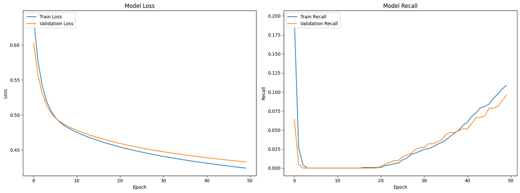

```python
# Create a figure with two subplots side by side
fig, axs = plt.subplots(1, 2, figsize=(16, 6))  # 1 row, 2 columns

# Plot Train Loss vs Validation Loss
axs[0].plot(history_0.history['loss'], label='Train Loss')
axs[0].plot(history_0.history['val_loss'], label='Validation Loss')
axs[0].set_title('Model Loss')
axs[0].set_ylabel('Loss')
axs[0].set_xlabel('Epoch')
axs[0].legend(loc='upper left')

# Plot Train Recall vs Validation Recall
axs[1].plot(history_0.history['Recall'], label='Train Recall')
axs[1].plot(history_0.history['val_Recall'], label='Validation Recall')
axs[1].set_title('Model Recall')
axs[1].set_ylabel('Recall')
axs[1].set_xlabel('Epoch')
axs[1].legend(loc='upper left')

# Adjust layout to avoid overlap
plt.tight_layout()

# Show the plots
plt.show()
```

```python
#Predicting the results using best as a threshold
y_train_pred = model_0.predict(X_train)
y_train_pred = (y_train_pred > 0.5)
y_train_pred
```

```
188/188 ━━━━━━━━━━━━━━━━━━━━ 1s 5ms/step
```

```
array([[False],
       [False],
       [False],
       ...,
       [False],
       [False],
       [False]])
```

```python
#Predicting the results using best as a threshold
y_val_pred = model_0.predict(X_val)
y_val_pred = (y_val_pred > 0.5)
y_val_pred
```

```
63/63 ━━━━━━━━━━━━━━━━━━━━ 0s 6ms/step
```

```
array([[False],
       [False],
       [False],
       ...,
       [False],
       [False],
       [False]])
```

```python
# Calculate recall for training and validation sets
train_recall = recall_score(y_train, y_train_pred)
valid_recall = recall_score(y_val, y_val_pred)

# Calculate the difference between training and validation recall
recall_difference = train_recall - valid_recall
```

```python
model_name = "NN with SGD"

# Append the metrics to the DataFrame
metrics_df.loc[model_name] = {
    "train_recall": train_recall,
    "valid_recall": valid_recall,
    "recall_difference": recall_difference
}
```

**Classification report**

```python
# Generate and combine classification reports for training and validation datasets
cr_df = pd.concat([
    pd.DataFrame(classification_report(y_train, y_train_pred, output_dict=True)).transpose().assign(datasets='Training'),
    pd.DataFrame(classification_report(y_val, y_val_pred, output_dict=True)).transpose().assign(datasets='Validation')
]).reset_index().set_index('datasets').rename(columns={'index': 'metrics'})

# Display the combined table
cr_df
```

| datasets | metrics | precision | recall | f1-score | support |
| --- | --- | --- | --- | --- | --- |
| Training | 0 | 0.811549 | 0.982625 | 0.888931 | 4777.0000 |
| Training | 1 | 0.615741 | 0.108749 | 0.184851 | 1223.0000 |
| Training | accuracy | 0.804500 | 0.804500 | 0.804500 | 0.8045 |
| Training | macro avg | 0.713645 | 0.545687 | 0.536891 | 6000.0000 |
| Training | weighted avg | 0.771637 | 0.804500 | 0.745416 | 6000.0000 |
| Validation | 0 | 0.810114 | 0.985562 | 0.889266 | 1593.0000 |
| Validation | 1 | 0.629032 | 0.095823 | 0.166311 | 407.0000 |
| Validation | accuracy | 0.804500 | 0.804500 | 0.804500 | 0.8045 |
| Validation | macro avg | 0.719573 | 0.540692 | 0.527789 | 2000.0000 |
| Validation | weighted avg | 0.773263 | 0.804500 | 0.742145 | 2000.0000 |

- The model shows high precision and recall for the majority class (0) on both training and validation sets, but performs poorly for the minority class (1).
- Imbalance is reflected in the macro and weighted average metrics, which are considerably lower than the accuracy score.
- In order to improve the overall model performance we must address the class imbalance using SMOTE techniques with or without DropOut.

**Confusion matrix**

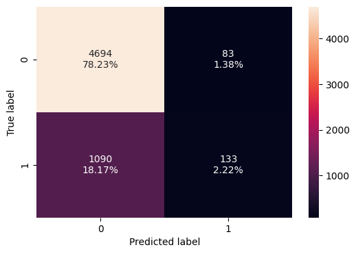

```python
make_confusion_matrix(y_train, y_train_pred)
```

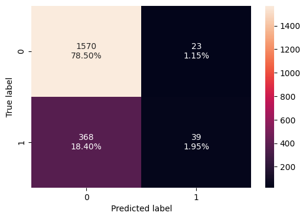

```python
make_confusion_matrix(y_val, y_val_pred)
```

## Model Performance Improvement

### Neural Network with Adam Optimizer

```python
backend.clear_session()
#Fixing the seed for random number generators so that we can ensure we receive the same output everytime
np.random.seed(2)
random.seed(2)
tf.random.set_seed(2)
```

```python
# Initializing the neural network
model_1 = Sequential()

# Adding the input layer with 64 neurons and relu as activation function
model_1.add(Dense(64, activation='relu', input_dim=X_train.shape[1]))

# Adding a hidden layer with 32 neurons and relu as activation function
model_1.add(Dense(32, activation='relu'))

# Adding the output layer with 1 neuron (for binary classification) and sigmoid activation function
model_1.add(Dense(1, activation='sigmoid'))
```

```python
from tensorflow.keras.optimizers import Adam
from tensorflow.keras.metrics import Recall

# Compiling the model with binary cross entropy as loss function and recall as the metric
optimizer = Adam(learning_rate=0.001)
metric = 'Recall'  # Use Recall as a callable object from tensorflow.keras.metrics
model_1.compile(loss='binary_crossentropy', optimizer=optimizer, metrics=[metric])
```

```python
model_1.summary()
```

```
Model: "sequential"
```

```
┏━━━━━━━━━━━━━━━━━━━━━━━━━━━━━━━━━━━━━━┳━━━━━━━━━━━━━━━━━━━━━━━━━━━━━┳━━━━━━━━━━━━━━━━━┓
┃ Layer (type)                         ┃ Output Shape                ┃         Param # ┃
┡━━━━━━━━━━━━━━━━━━━━━━━━━━━━━━━━━━━━━━╇━━━━━━━━━━━━━━━━━━━━━━━━━━━━━╇━━━━━━━━━━━━━━━━━┩
│ dense (Dense)                        │ (None, 64)                  │             768 │
├──────────────────────────────────────┼─────────────────────────────┼─────────────────┤
│ dense_1 (Dense)                      │ (None, 32)                  │           2,080 │
├──────────────────────────────────────┼─────────────────────────────┼─────────────────┤
│ dense_2 (Dense)                      │ (None, 1)                   │              33 │
└──────────────────────────────────────┴─────────────────────────────┴─────────────────┘
```

```
 Total params: 2,881 (11.25 KB)
```

```
 Trainable params: 2,881 (11.25 KB)
```

```
 Non-trainable params: 0 (0.00 B)
```

```python
# Fitting the ANN
history_1 = model_1.fit(
    X_train, y_train,
    batch_size=32,  # Specify the batch size to use
    validation_data=(X_val, y_val),
    epochs=50,  # Specify the number of epochs
    verbose=1
)
```

```
188/188 ━━━━━━━━━━━━━━━━━━━━ 15s 81ms/step - Recall: 0.0447 - loss: 0.4996 - val_Recall: 0.2998 - val_loss: 0.4087
188/188 ━━━━━━━━━━━━━━━━━━━━ 23s 124ms/step - Recall: 0.3052 - loss: 0.3812 - val_Recall: 0.4226 - val_loss: 0.3747
188/188 ━━━━━━━━━━━━━━━━━━━━ 33s 80ms/step - Recall: 0.4145 - loss: 0.3505 - val_Recall: 0.4570 - val_loss: 0.3646
188/188 ━━━━━━━━━━━━━━━━━━━━ 20s 79ms/step - Recall: 0.4383 - loss: 0.3399 - val_Recall: 0.4496 - val_loss: 0.3617
188/188 ━━━━━━━━━━━━━━━━━━━━ 20s 78ms/step - Recall: 0.4555 - loss: 0.3345 - val_Recall: 0.4496 - val_loss: 0.3601
188/188 ━━━━━━━━━━━━━━━━━━━━ 15s 79ms/step - Recall: 0.4575 - loss: 0.3307 - val_Recall: 0.4570 - val_loss: 0.3592
188/188 ━━━━━━━━━━━━━━━━━━━━ 15s 82ms/step - Recall: 0.4622 - loss: 0.3273 - val_Recall: 0.4521 - val_loss: 0.3586
188/188 ━━━━━━━━━━━━━━━━━━━━ 15s 80ms/step - Recall: 0.4686 - loss: 0.3246 - val_Recall: 0.4447 - val_loss: 0.3580
188/188 ━━━━━━━━━━━━━━━━━━━━ 21s 82ms/step - Recall: 0.4708 - loss: 0.3221 - val_Recall: 0.4423 - val_loss: 0.3577
188/188 ━━━━━━━━━━━━━━━━━━━━ 21s 87ms/step - Recall: 0.4720 - loss: 0.3197 - val_Recall: 0.4423 - val_loss: 0.3578
188/188 ━━━━━━━━━━━━━━━━━━━━ 16s 84ms/step - Recall: 0.4798 - loss: 0.3179 - val_Recall: 0.4447 - val_loss: 0.3575
188/188 ━━━━━━━━━━━━━━━━━━━━ 16s 83ms/step - Recall: 0.4889 - loss: 0.3161 - val_Recall: 0.4472 - val_loss: 0.3574
188/188 ━━━━━━━━━━━━━━━━━━━━ 17s 90ms/step - Recall: 0.4882 - loss: 0.3144 - val_Recall: 0.4496 - val_loss: 0.3571
188/188 ━━━━━━━━━━━━━━━━━━━━ 19s 84ms/step - Recall: 0.4890 - loss: 0.3127 - val_Recall: 0.4496 - val_loss: 0.3568
188/188 ━━━━━━━━━━━━━━━━━━━━ 15s 80ms/step - Recall: 0.4897 - loss: 0.3111 - val_Recall: 0.4521 - val_loss: 0.3565
188/188 ━━━━━━━━━━━━━━━━━━━━ 15s 80ms/step - Recall: 0.4924 - loss: 0.3096 - val_Recall: 0.4496 - val_loss: 0.3564
188/188 ━━━━━━━━━━━━━━━━━━━━ 15s 80ms/step - Recall: 0.4923 - loss: 0.3082 - val_Recall: 0.4472 - val_loss: 0.3561
188/188 ━━━━━━━━━━━━━━━━━━━━ 21s 83ms/step - Recall: 0.4933 - loss: 0.3067 - val_Recall: 0.4496 - val_loss: 0.3560
188/188 ━━━━━━━━━━━━━━━━━━━━ 21s 87ms/step - Recall: 0.4956 - loss: 0.3054 - val_Recall: 0.4521 - val_loss: 0.3562
188/188 ━━━━━━━━━━━━━━━━━━━━ 16s 86ms/step - Recall: 0.4953 - loss: 0.3040 - val_Recall: 0.4521 - val_loss: 0.3560
188/188 ━━━━━━━━━━━━━━━━━━━━ 15s 81ms/step - Recall: 0.4972 - loss: 0.3028 - val_Recall: 0.4545 - val_loss: 0.3559
188/188 ━━━━━━━━━━━━━━━━━━━━ 15s 82ms/step - Recall: 0.5037 - loss: 0.3016 - val_Recall: 0.4545 - val_loss: 0.3559
188/188 ━━━━━━━━━━━━━━━━━━━━ 15s 81ms/step - Recall: 0.5081 - loss: 0.3002 - val_Recall: 0.4570 - val_loss: 0.3559
188/188 ━━━━━━━━━━━━━━━━━━━━ 15s 82ms/step - Recall: 0.5091 - loss: 0.2992 - val_Recall: 0.4595 - val_loss: 0.3562
188/188 ━━━━━━━━━━━━━━━━━━━━ 21s 85ms/step - Recall: 0.5124 - loss: 0.2981 - val_Recall: 0.4595 - val_loss: 0.3563
188/188 ━━━━━━━━━━━━━━━━━━━━ 17s 90ms/step - Recall: 0.5209 - loss: 0.2971 - val_Recall: 0.4619 - val_loss: 0.3564
188/188 ━━━━━━━━━━━━━━━━━━━━ 25s 131ms/step - Recall: 0.5176 - loss: 0.2961 - val_Recall: 0.4619 - val_loss: 0.3565
188/188 ━━━━━━━━━━━━━━━━━━━━ 25s 132ms/step - Recall: 0.5147 - loss: 0.2950 - val_Recall: 0.4619 - val_loss: 0.3567
188/188 ━━━━━━━━━━━━━━━━━━━━ 15s 80ms/step - Recall: 0.5217 - loss: 0.2939 - val_Recall: 0.4545 - val_loss: 0.3564
188/188 ━━━━━━━━━━━━━━━━━━━━ 15s 79ms/step - Recall: 0.5239 - loss: 0.2931 - val_Recall: 0.4521 - val_loss: 0.3568
188/188 ━━━━━━━━━━━━━━━━━━━━ 21s 81ms/step - Recall: 0.5276 - loss: 0.2922 - val_Recall: 0.4570 - val_loss: 0.3571
188/188 ━━━━━━━━━━━━━━━━━━━━ 23s 122ms/step - Recall: 0.5279 - loss: 0.2914 - val_Recall: 0.4570 - val_loss: 0.3574
188/188 ━━━━━━━━━━━━━━━━━━━━ 35s 91ms/step - Recall: 0.5304 - loss: 0.2905 - val_Recall: 0.4570 - val_loss: 0.3578
188/188 ━━━━━━━━━━━━━━━━━━━━ 20s 89ms/step - Recall: 0.5346 - loss: 0.2895 - val_Recall: 0.4595 - val_loss: 0.3583
188/188 ━━━━━━━━━━━━━━━━━━━━ 34s 182ms/step - Recall: 0.5319 - loss: 0.2888 - val_Recall: 0.4619 - val_loss: 0.3587
188/188 ━━━━━━━━━━━━━━━━━━━━ 22s 117ms/step - Recall: 0.5322 - loss: 0.2879 - val_Recall: 0.4595 - val_loss: 0.3591
188/188 ━━━━━━━━━━━━━━━━━━━━ 34s 82ms/step - Recall: 0.5386 - loss: 0.2872 - val_Recall: 0.4595 - val_loss: 0.3595
188/188 ━━━━━━━━━━━━━━━━━━━━ 15s 82ms/step - Recall: 0.5380 - loss: 0.2864 - val_Recall: 0.4595 - val_loss: 0.3598
188/188 ━━━━━━━━━━━━━━━━━━━━ 15s 82ms/step - Recall: 0.5417 - loss: 0.2857 - val_Recall: 0.4595 - val_loss: 0.3605
188/188 ━━━━━━━━━━━━━━━━━━━━ 24s 128ms/step - Recall: 0.5445 - loss: 0.2849 - val_Recall: 0.4619 - val_loss: 0.3611
188/188 ━━━━━━━━━━━━━━━━━━━━ 33s 84ms/step - Recall: 0.5490 - loss: 0.2840 - val_Recall: 0.4595 - val_loss: 0.3614
188/188 ━━━━━━━━━━━━━━━━━━━━ 17s 90ms/step - Recall: 0.5483 - loss: 0.2830 - val_Recall: 0.4595 - val_loss: 0.3619
188/188 ━━━━━━━━━━━━━━━━━━━━ 19s 85ms/step - Recall: 0.5492 - loss: 0.2821 - val_Recall: 0.4619 - val_loss: 0.3622
188/188 ━━━━━━━━━━━━━━━━━━━━ 20s 83ms/step - Recall: 0.5487 - loss: 0.2813 - val_Recall: 0.4644 - val_loss: 0.3629
188/188 ━━━━━━━━━━━━━━━━━━━━ 17s 90ms/step - Recall: 0.5567 - loss: 0.2806 - val_Recall: 0.4644 - val_loss: 0.3633
188/188 ━━━━━━━━━━━━━━━━━━━━ 21s 91ms/step - Recall: 0.5555 - loss: 0.2796 - val_Recall: 0.4644 - val_loss: 0.3640
188/188 ━━━━━━━━━━━━━━━━━━━━ 18s 94ms/step - Recall: 0.5614 - loss: 0.2788 - val_Recall: 0.4644 - val_loss: 0.3643
188/188 ━━━━━━━━━━━━━━━━━━━━ 19s 87ms/step - Recall: 0.5597 - loss: 0.2781 - val_Recall: 0.4644 - val_loss: 0.3653
188/188 ━━━━━━━━━━━━━━━━━━━━ 20s 87ms/step - Recall: 0.5542 - loss: 0.2772 - val_Recall: 0.4570 - val_loss: 0.3661
188/188 ━━━━━━━━━━━━━━━━━━━━ 16s 86ms/step - Recall: 0.5613 - loss: 0.2763 - val_Recall: 0.4595 - val_loss: 0.3668
```

#### **Loss function and Recall**

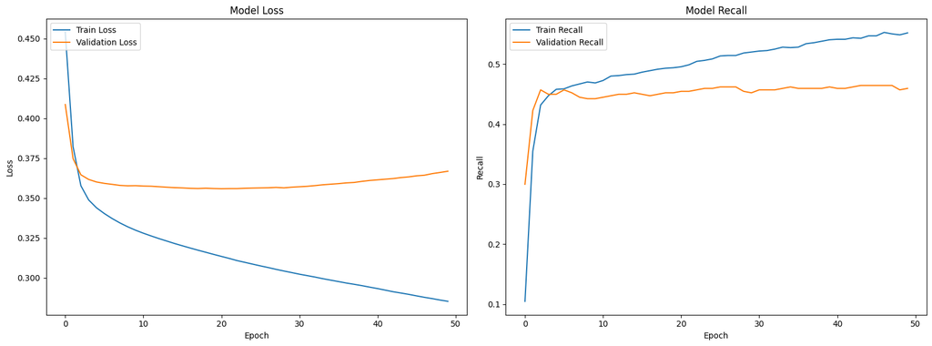

```python
# Create a figure with two subplots side by side
fig, axs = plt.subplots(1, 2, figsize=(16, 6))  # 1 row, 2 columns

# Plot Train Loss vs Validation Loss
axs[0].plot(history_1.history['loss'], label='Train Loss')
axs[0].plot(history_1.history['val_loss'], label='Validation Loss')
axs[0].set_title('Model Loss')
axs[0].set_ylabel('Loss')
axs[0].set_xlabel('Epoch')
axs[0].legend(loc='upper left')

# Plot Train Recall vs Validation Recall
axs[1].plot(history_1.history['Recall'], label='Train Recall')
axs[1].plot(history_1.history['val_Recall'], label='Validation Recall')
axs[1].set_title('Model Recall')
axs[1].set_ylabel('Recall')
axs[1].set_xlabel('Epoch')
axs[1].legend(loc='upper left')

# Adjust layout to avoid overlap
plt.tight_layout()

# Show the plots
plt.show()
```

- During the initial training phase, the loss function shows a decrease, indicating effective learning. However, the validation loss remains stable earlier than the training loss, suggesting a potential overfitting.
- Recall improves for both training and validation sets over the epochs, but the widening gap between them suggests that the model is overfitting.

```python
#Predicting the results using 0.5 as the threshold
y_train_pred = model_1.predict(X_train)
y_train_pred = (y_train_pred > 0.5)
y_train_pred
```

```
188/188 ━━━━━━━━━━━━━━━━━━━━ 1s 6ms/step
```

```
array([[False],
       [False],
       [ True],
       ...,
       [ True],
       [False],
       [ True]])
```

```python
#Predicting the results using 0.5 as the threshold
y_val_pred = model_1.predict(X_val)
y_val_pred = (y_val_pred > 0.5)
y_val_pred
```

```
63/63 ━━━━━━━━━━━━━━━━━━━━ 0s 6ms/step
```

```
array([[False],
       [False],
       [ True],
       ...,
       [False],
       [False],
       [False]])
```

```python
# Calculate recall for training and validation sets
train_recall = recall_score(y_train, y_train_pred)
valid_recall = recall_score(y_val, y_val_pred)

# Calculate the difference between training and validation recall
recall_difference = train_recall - valid_recall
```

```python
model_name = "ANN with Adam"

# Append the metrics to the DataFrame
metrics_df.loc[model_name] = {
    "train_recall": train_recall,
    "valid_recall": valid_recall,
    "recall_difference": recall_difference
}
```

**Classification report**

```python
# Classification reports for training and validation datasets
cr_df = pd.concat([
    pd.DataFrame(classification_report(y_train, y_train_pred, output_dict=True)).transpose().assign(datasets='Training'),
    pd.DataFrame(classification_report(y_val, y_val_pred, output_dict=True)).transpose().assign(datasets='Validation')
]).reset_index().set_index('datasets').rename(columns={'index': 'metrics'})

# Display the classification table
print(f"Classification Report: {model_name}\n")
cr_df
```

```
Classification Report: ANN with Adam
```

| datasets | metrics | precision | recall | f1-score | support |
| --- | --- | --- | --- | --- | --- |
| Training | 0 | 0.899648 | 0.962738 | 0.930124 | 4777.000000 |
| Training | 1 | 0.799550 | 0.580540 | 0.672667 | 1223.000000 |
| Training | accuracy | 0.884833 | 0.884833 | 0.884833 | 0.884833 |
| Training | macro avg | 0.849599 | 0.771639 | 0.801396 | 6000.000000 |
| Training | weighted avg | 0.879245 | 0.884833 | 0.877646 | 6000.000000 |
| Validation | 0 | 0.873199 | 0.951036 | 0.910457 | 1593.000000 |
| Validation | 1 | 0.705660 | 0.459459 | 0.556548 | 407.000000 |
| Validation | accuracy | 0.851000 | 0.851000 | 0.851000 | 0.851000 |
| Validation | macro avg | 0.789430 | 0.705248 | 0.733502 | 2000.000000 |
| Validation | weighted avg | 0.839105 | 0.851000 | 0.838436 | 2000.000000 |

- The model using the Adam optimizer demonstrates a strong performance on the majority class (0) but struggles with the minority class (1). While precision, recall, and F1-score are high for the majority class, they are significantly lower for the minority class, indicating class imbalance.
- The model architecture is relatively simple with two dense layers, which might be limiting its ability to capture complex patterns in the data, especially for the minority class.

**Confusion matrix**

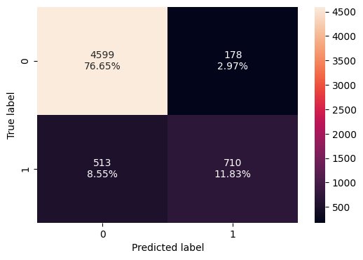

```python
#Calculating the confusion matrix
make_confusion_matrix(y_train, y_train_pred)
```

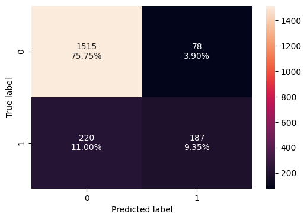

```python
#Calculating the confusion matrix
make_confusion_matrix(y_val, y_val_pred)
```

### Neural Network with Adam Optimizer and Dropout

```python
backend.clear_session()
#Fixing the seed for random number generators so that we can ensure we receive the same output everytime
np.random.seed(2)
random.seed(2)
tf.random.set_seed(2)
```

```python
# Initializing the neural network
model_2 = Sequential()

# Adding the input layer with 32 neurons and relu as activation function
model_2.add(Dense(32, activation='relu', input_dim=X_train.shape[1]))

# Adding dropout with a ratio of 0.2
model_2.add(Dropout(0.2))

# Adding a hidden layer with 64 neurons and relu as activation function
model_2.add(Dense(64, activation='relu'))

# Adding a hidden layer with 32 neurons and relu as activation function
model_2.add(Dense(32, activation='relu'))

# Adding dropout with a ratio of 0.1
model_2.add(Dropout(0.1))

# Adding a hidden layer with 16 neurons and relu as activation function
model_2.add(Dense(16, activation='relu'))

# Adding the output layer with 1 neuron (for binary classification) and sigmoid activation function
model_2.add(Dense(1, activation='sigmoid'))
```

```python
# Define the Adam optimizer
optimizer = Adam(learning_rate=0.001)

# Compile the model with binary cross entropy as loss function and recall as the metric
metric = 'Recall'
model_2.compile(loss='binary_crossentropy', optimizer=optimizer, metrics=[metric])
```

```python
# Summary of the model
model_2.summary()
```

```
Model: "sequential"
```

```
┏━━━━━━━━━━━━━━━━━━━━━━━━━━━━━━━━━━━━━━┳━━━━━━━━━━━━━━━━━━━━━━━━━━━━━┳━━━━━━━━━━━━━━━━━┓
┃ Layer (type)                         ┃ Output Shape                ┃         Param # ┃
┡━━━━━━━━━━━━━━━━━━━━━━━━━━━━━━━━━━━━━━╇━━━━━━━━━━━━━━━━━━━━━━━━━━━━━╇━━━━━━━━━━━━━━━━━┩
│ dense (Dense)                        │ (None, 32)                  │             384 │
├──────────────────────────────────────┼─────────────────────────────┼─────────────────┤
│ dropout (Dropout)                    │ (None, 32)                  │               0 │
├──────────────────────────────────────┼─────────────────────────────┼─────────────────┤
│ dense_1 (Dense)                      │ (None, 64)                  │           2,112 │
├──────────────────────────────────────┼─────────────────────────────┼─────────────────┤
│ dense_2 (Dense)                      │ (None, 32)                  │           2,080 │
├──────────────────────────────────────┼─────────────────────────────┼─────────────────┤
│ dropout_1 (Dropout)                  │ (None, 32)                  │               0 │
├──────────────────────────────────────┼─────────────────────────────┼─────────────────┤
│ dense_3 (Dense)                      │ (None, 16)                  │             528 │
├──────────────────────────────────────┼─────────────────────────────┼─────────────────┤
│ dense_4 (Dense)                      │ (None, 1)                   │              17 │
└──────────────────────────────────────┴─────────────────────────────┴─────────────────┘
```

```
 Total params: 5,121 (20.00 KB)
```

```
 Trainable params: 5,121 (20.00 KB)
```

```
 Non-trainable params: 0 (0.00 B)
```

```python
# Fitting the ANN with batch_size = 32 and 100 epochs
history_2 = model_2.fit(
    X_train, y_train,
    batch_size=32,
    epochs=100,
    verbose=1,
    validation_data=(X_val, y_val)
)
```

```
188/188 ━━━━━━━━━━━━━━━━━━━━ 29s 154ms/step - Recall: 0.0512 - loss: 0.5139 - val_Recall: 0.0025 - val_loss: 0.4324
188/188 ━━━━━━━━━━━━━━━━━━━━ 23s 122ms/step - Recall: 0.1027 - loss: 0.4187 - val_Recall: 0.3366 - val_loss: 0.3849
188/188 ━━━━━━━━━━━━━━━━━━━━ 42s 125ms/step - Recall: 0.3014 - loss: 0.3856 - val_Recall: 0.3833 - val_loss: 0.3660
188/188 ━━━━━━━━━━━━━━━━━━━━ 40s 121ms/step - Recall: 0.3878 - loss: 0.3642 - val_Recall: 0.4079 - val_loss: 0.3612
188/188 ━━━━━━━━━━━━━━━━━━━━ 40s 117ms/step - Recall: 0.4143 - loss: 0.3520 - val_Recall: 0.4152 - val_loss: 0.3599
188/188 ━━━━━━━━━━━━━━━━━━━━ 40s 114ms/step - Recall: 0.4081 - loss: 0.3503 - val_Recall: 0.4226 - val_loss: 0.3575
188/188 ━━━━━━━━━━━━━━━━━━━━ 23s 121ms/step - Recall: 0.4168 - loss: 0.3452 - val_Recall: 0.4324 - val_loss: 0.3543
188/188 ━━━━━━━━━━━━━━━━━━━━ 23s 120ms/step - Recall: 0.4269 - loss: 0.3425 - val_Recall: 0.4668 - val_loss: 0.3539
188/188 ━━━━━━━━━━━━━━━━━━━━ 23s 123ms/step - Recall: 0.4430 - loss: 0.3390 - val_Recall: 0.4472 - val_loss: 0.3528
188/188 ━━━━━━━━━━━━━━━━━━━━ 41s 121ms/step - Recall: 0.4302 - loss: 0.3422 - val_Recall: 0.4545 - val_loss: 0.3518
188/188 ━━━━━━━━━━━━━━━━━━━━ 23s 120ms/step - Recall: 0.4448 - loss: 0.3377 - val_Recall: 0.4889 - val_loss: 0.3558
188/188 ━━━━━━━━━━━━━━━━━━━━ 41s 120ms/step - Recall: 0.4551 - loss: 0.3338 - val_Recall: 0.4668 - val_loss: 0.3527
188/188 ━━━━━━━━━━━━━━━━━━━━ 41s 120ms/step - Recall: 0.4232 - loss: 0.3371 - val_Recall: 0.4693 - val_loss: 0.3515
188/188 ━━━━━━━━━━━━━━━━━━━━ 23s 121ms/step - Recall: 0.4735 - loss: 0.3272 - val_Recall: 0.4889 - val_loss: 0.3534
188/188 ━━━━━━━━━━━━━━━━━━━━ 40s 118ms/step - Recall: 0.4588 - loss: 0.3304 - val_Recall: 0.4324 - val_loss: 0.3519
188/188 ━━━━━━━━━━━━━━━━━━━━ 42s 124ms/step - Recall: 0.4730 - loss: 0.3249 - val_Recall: 0.4767 - val_loss: 0.3515
188/188 ━━━━━━━━━━━━━━━━━━━━ 22s 119ms/step - Recall: 0.4802 - loss: 0.3238 - val_Recall: 0.4717 - val_loss: 0.3521
188/188 ━━━━━━━━━━━━━━━━━━━━ 41s 122ms/step - Recall: 0.4761 - loss: 0.3274 - val_Recall: 0.4619 - val_loss: 0.3528
188/188 ━━━━━━━━━━━━━━━━━━━━ 23s 122ms/step - Recall: 0.4608 - loss: 0.3257 - val_Recall: 0.4791 - val_loss: 0.3530
188/188 ━━━━━━━━━━━━━━━━━━━━ 23s 122ms/step - Recall: 0.4773 - loss: 0.3230 - val_Recall: 0.4865 - val_loss: 0.3545
188/188 ━━━━━━━━━━━━━━━━━━━━ 23s 123ms/step - Recall: 0.4711 - loss: 0.3237 - val_Recall: 0.4693 - val_loss: 0.3516
188/188 ━━━━━━━━━━━━━━━━━━━━ 41s 125ms/step - Recall: 0.4810 - loss: 0.3201 - val_Recall: 0.4644 - val_loss: 0.3513
188/188 ━━━━━━━━━━━━━━━━━━━━ 41s 125ms/step - Recall: 0.4616 - loss: 0.3246 - val_Recall: 0.4767 - val_loss: 0.3534
188/188 ━━━━━━━━━━━━━━━━━━━━ 40s 118ms/step - Recall: 0.4911 - loss: 0.3210 - val_Recall: 0.4472 - val_loss: 0.3508
188/188 ━━━━━━━━━━━━━━━━━━━━ 24s 127ms/step - Recall: 0.4799 - loss: 0.3181 - val_Recall: 0.4963 - val_loss: 0.3525
188/188 ━━━━━━━━━━━━━━━━━━━━ 23s 125ms/step - Recall: 0.4707 - loss: 0.3201 - val_Recall: 0.4963 - val_loss: 0.3530
188/188 ━━━━━━━━━━━━━━━━━━━━ 25s 130ms/step - Recall: 0.4861 - loss: 0.3149 - val_Recall: 0.4767 - val_loss: 0.3515
188/188 ━━━━━━━━━━━━━━━━━━━━ 25s 134ms/step - Recall: 0.4826 - loss: 0.3181 - val_Recall: 0.4767 - val_loss: 0.3517
188/188 ━━━━━━━━━━━━━━━━━━━━ 24s 129ms/step - Recall: 0.4729 - loss: 0.3159 - val_Recall: 0.4840 - val_loss: 0.3541
188/188 ━━━━━━━━━━━━━━━━━━━━ 40s 122ms/step - Recall: 0.4795 - loss: 0.3141 - val_Recall: 0.4595 - val_loss: 0.3509
188/188 ━━━━━━━━━━━━━━━━━━━━ 42s 125ms/step - Recall: 0.4640 - loss: 0.3127 - val_Recall: 0.4693 - val_loss: 0.3535
188/188 ━━━━━━━━━━━━━━━━━━━━ 25s 135ms/step - Recall: 0.4660 - loss: 0.3173 - val_Recall: 0.4570 - val_loss: 0.3527
188/188 ━━━━━━━━━━━━━━━━━━━━ 40s 131ms/step - Recall: 0.4767 - loss: 0.3102 - val_Recall: 0.4840 - val_loss: 0.3548
188/188 ━━━━━━━━━━━━━━━━━━━━ 22s 119ms/step - Recall: 0.5045 - loss: 0.3098 - val_Recall: 0.4840 - val_loss: 0.3571
188/188 ━━━━━━━━━━━━━━━━━━━━ 24s 129ms/step - Recall: 0.4903 - loss: 0.3126 - val_Recall: 0.4619 - val_loss: 0.3526
188/188 ━━━━━━━━━━━━━━━━━━━━ 40s 125ms/step - Recall: 0.4924 - loss: 0.3127 - val_Recall: 0.4619 - val_loss: 0.3534
188/188 ━━━━━━━━━━━━━━━━━━━━ 22s 117ms/step - Recall: 0.4872 - loss: 0.3133 - val_Recall: 0.4840 - val_loss: 0.3529
188/188 ━━━━━━━━━━━━━━━━━━━━ 41s 116ms/step - Recall: 0.4836 - loss: 0.3109 - val_Recall: 0.4570 - val_loss: 0.3526
188/188 ━━━━━━━━━━━━━━━━━━━━ 42s 121ms/step - Recall: 0.4751 - loss: 0.3105 - val_Recall: 0.4816 - val_loss: 0.3553
188/188 ━━━━━━━━━━━━━━━━━━━━ 24s 125ms/step - Recall: 0.4716 - loss: 0.3104 - val_Recall: 0.4668 - val_loss: 0.3526
```

[output cut: 45 more lines]

```
188/188 ━━━━━━━━━━━━━━━━━━━━ 41s 123ms/step - Recall: 0.5374 - loss: 0.2834 - val_Recall: 0.4644 - val_loss: 0.3748
188/188 ━━━━━━━━━━━━━━━━━━━━ 24s 128ms/step - Recall: 0.5365 - loss: 0.2898 - val_Recall: 0.4693 - val_loss: 0.3756
188/188 ━━━━━━━━━━━━━━━━━━━━ 23s 123ms/step - Recall: 0.5109 - loss: 0.2861 - val_Recall: 0.4939 - val_loss: 0.3768
188/188 ━━━━━━━━━━━━━━━━━━━━ 24s 127ms/step - Recall: 0.5301 - loss: 0.2906 - val_Recall: 0.5111 - val_loss: 0.3766
188/188 ━━━━━━━━━━━━━━━━━━━━ 23s 124ms/step - Recall: 0.5174 - loss: 0.2900 - val_Recall: 0.4939 - val_loss: 0.3779
188/188 ━━━━━━━━━━━━━━━━━━━━ 41s 126ms/step - Recall: 0.5329 - loss: 0.2847 - val_Recall: 0.4865 - val_loss: 0.3784
188/188 ━━━━━━━━━━━━━━━━━━━━ 41s 125ms/step - Recall: 0.5020 - loss: 0.2927 - val_Recall: 0.5037 - val_loss: 0.3767
188/188 ━━━━━━━━━━━━━━━━━━━━ 41s 125ms/step - Recall: 0.5306 - loss: 0.2864 - val_Recall: 0.5184 - val_loss: 0.3831
188/188 ━━━━━━━━━━━━━━━━━━━━ 40s 122ms/step - Recall: 0.5358 - loss: 0.2856 - val_Recall: 0.4939 - val_loss: 0.3816
188/188 ━━━━━━━━━━━━━━━━━━━━ 24s 126ms/step - Recall: 0.5108 - loss: 0.2907 - val_Recall: 0.4742 - val_loss: 0.3787
188/188 ━━━━━━━━━━━━━━━━━━━━ 41s 126ms/step - Recall: 0.5258 - loss: 0.2910 - val_Recall: 0.4889 - val_loss: 0.3768
188/188 ━━━━━━━━━━━━━━━━━━━━ 41s 128ms/step - Recall: 0.5307 - loss: 0.2892 - val_Recall: 0.4840 - val_loss: 0.3816
188/188 ━━━━━━━━━━━━━━━━━━━━ 24s 125ms/step - Recall: 0.5231 - loss: 0.2867 - val_Recall: 0.4889 - val_loss: 0.3791
188/188 ━━━━━━━━━━━━━━━━━━━━ 25s 131ms/step - Recall: 0.5251 - loss: 0.2899 - val_Recall: 0.4791 - val_loss: 0.3812
188/188 ━━━━━━━━━━━━━━━━━━━━ 24s 126ms/step - Recall: 0.5463 - loss: 0.2826 - val_Recall: 0.4865 - val_loss: 0.3852
```

#### **Loss function and Recall**

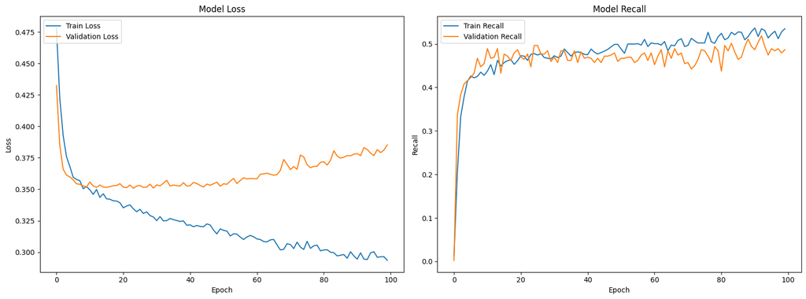

```python
# Create a figure with two subplots side by side
fig, axs = plt.subplots(1, 2, figsize=(16, 6))  # 1 row, 2 columns

# Plot Train Loss vs Validation Loss
axs[0].plot(history_2.history['loss'], label='Train Loss')
axs[0].plot(history_2.history['val_loss'], label='Validation Loss')
axs[0].set_title('Model Loss')
axs[0].set_ylabel('Loss')
axs[0].set_xlabel('Epoch')
axs[0].legend(loc='upper left')

# Plot Train Recall vs Validation Recall
axs[1].plot(history_2.history['Recall'], label='Train Recall')
axs[1].plot(history_2.history['val_Recall'], label='Validation Recall')
axs[1].set_title('Model Recall')
axs[1].set_ylabel('Recall')
axs[1].set_xlabel('Epoch')
axs[1].legend(loc='upper left')

# Adjust layout to avoid overlap
plt.tight_layout()

# Show the plots
plt.show()
```

The model exhibits a typical learning curve with initial improvement followed by overfitting. The widening gap between training and validation metrics, particularly after the 20th epoch, highlights the need for techniques like early stopping, regularization, or data augmentation to enhance the model's generalization ability.

```python
#Predicting the results using best as a threshold
y_train_pred = model_2.predict(X_train)
y_train_pred = (y_train_pred > 0.5)
y_train_pred
```

```
188/188 ━━━━━━━━━━━━━━━━━━━━ 3s 14ms/step
```

```
array([[False],
       [False],
       [ True],
       ...,
       [ True],
       [False],
       [ True]])
```

```python
#Predicting the results using 0.5 as the threshold.
y_val_pred = model_2.predict(X_val)
y_val_pred = (y_val_pred > 0.5)
y_val_pred
```

```
63/63 ━━━━━━━━━━━━━━━━━━━━ 1s 10ms/step
```

```
array([[False],
       [False],
       [False],
       ...,
       [False],
       [False],
       [ True]])
```

```python
# Calculate recall for training and validation sets
train_recall = recall_score(y_train, y_train_pred)
valid_recall = recall_score(y_val, y_val_pred)

# Calculate the difference between training and validation recall
recall_difference = train_recall - valid_recall
```

```python
model_name = "ANN with Adam & Dropout"

# Append the metrics to the DataFrame
metrics_df.loc[model_name] = {
    "train_recall": train_recall,
    "valid_recall": valid_recall,
    "recall_difference": recall_difference
}
```

**Classification report**

```python
# Generate and combine classification reports for training and validation datasets
cr_df = pd.concat([
    pd.DataFrame(classification_report(y_train, y_train_pred, output_dict=True)).transpose().assign(datasets='Training'),
    pd.DataFrame(classification_report(y_val, y_val_pred, output_dict=True)).transpose().assign(datasets='Validation')
]).reset_index().set_index('datasets').rename(columns={'index': 'metrices'})

# Display the combined table
print(f"Classification Report: {model_name}\n")
cr_df
```

```
Classification Report: ANN with Adam & Dropout
```

| datasets | metrices | precision | recall | f1-score | support |
| --- | --- | --- | --- | --- | --- |
| Training | 0 | 0.901915 | 0.966297 | 0.932996 | 4777.0000 |
| Training | 1 | 0.817460 | 0.589534 | 0.685036 | 1223.0000 |
| Training | accuracy | 0.889500 | 0.889500 | 0.889500 | 0.8895 |
| Training | macro avg | 0.859688 | 0.777915 | 0.809016 | 6000.0000 |
| Training | weighted avg | 0.884700 | 0.889500 | 0.882454 | 6000.0000 |
| Validation | 0 | 0.878063 | 0.944758 | 0.910191 | 1593.0000 |
| Validation | 1 | 0.692308 | 0.486486 | 0.571429 | 407.0000 |
| Validation | accuracy | 0.851500 | 0.851500 | 0.851500 | 0.8515 |
| Validation | macro avg | 0.785185 | 0.715622 | 0.740810 | 2000.0000 |
| Validation | weighted avg | 0.840262 | 0.851500 | 0.841252 | 2000.0000 |

- The model with Adam and Dropout shows improved performance compared to the previous model, in handling the minority class. It is still facing challenges with class imbalance, as metrics for the minority class are lower.
- The overall accuracy and F1-score have increased.
- The model architecture includes dropout layers to mitigate overfitting, which contributed a slight improvement in the performance.
- Further tuning techniques to address class imbalance can enhance the model's capability to accurately predict the minority class.

**Confusion matrix**

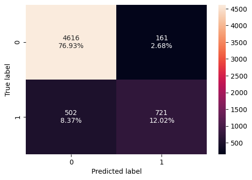

```python
#Calculating the confusion matrix
make_confusion_matrix(y_train, y_train_pred)
```

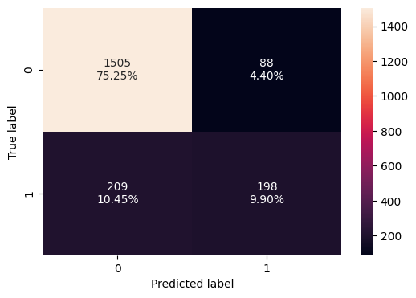

```python
#Calculating the confusion matrix
make_confusion_matrix(y_val, y_val_pred)
```

### Neural Network with Balanced Data (by applying SMOTE) and SGD Optimizer

**Let's try to apply SMOTE to balance this dataset and then again apply hyperparamter tuning accordingly.**

```python
sm = SMOTE(random_state=42)
#Complete the code to fit SMOTE on the training data.
X_train_smote, y_train_smote= sm.fit_resample(X_train, y_train)
print('After UpSampling, the shape of train_X: {}'.format(X_train_smote.shape))
print('After UpSampling, the shape of train_y: {} \n'.format(y_train_smote.shape))
```

```
After UpSampling, the shape of train_X: (9554, 11)
After UpSampling, the shape of train_y: (9554,)
```

```python
backend.clear_session()
#Fixing the seed for random number generators so that we can ensure we receive the same output everytime
np.random.seed(2)
random.seed(2)
tf.random.set_seed(2)
```

```python
# Initializing the model
model_3 = Sequential()

# Adding the input layer with 32 neurons and relu activation function
model_3.add(Dense(32, activation='relu', input_dim=X_train_smote.shape[1]))

# Adding a hidden layer with 16 neurons and relu activation function
model_3.add(Dense(16, activation='relu'))

# Adding another hidden layer with 8 neurons and relu activation function
model_3.add(Dense(8, activation='relu'))

# Adding the output layer with 1 neuron and sigmoid activation function (for binary classification)
model_3.add(Dense(1, activation='sigmoid'))
```

```python
# SGD as the optimizer with a learning rate of 0.001
optimizer = SGD(learning_rate=0.001)

metric = 'Recall'
model_3.compile(loss='binary_crossentropy', optimizer=optimizer, metrics=[metric])
```

```python
model_3.summary()
```

```
Model: "sequential"
```

```
┏━━━━━━━━━━━━━━━━━━━━━━━━━━━━━━━━━━━━━━┳━━━━━━━━━━━━━━━━━━━━━━━━━━━━━┳━━━━━━━━━━━━━━━━━┓
┃ Layer (type)                         ┃ Output Shape                ┃         Param # ┃
┡━━━━━━━━━━━━━━━━━━━━━━━━━━━━━━━━━━━━━━╇━━━━━━━━━━━━━━━━━━━━━━━━━━━━━╇━━━━━━━━━━━━━━━━━┩
│ dense (Dense)                        │ (None, 32)                  │             384 │
├──────────────────────────────────────┼─────────────────────────────┼─────────────────┤
│ dense_1 (Dense)                      │ (None, 16)                  │             528 │
├──────────────────────────────────────┼─────────────────────────────┼─────────────────┤
│ dense_2 (Dense)                      │ (None, 8)                   │             136 │
├──────────────────────────────────────┼─────────────────────────────┼─────────────────┤
│ dense_3 (Dense)                      │ (None, 1)                   │               9 │
└──────────────────────────────────────┴─────────────────────────────┴─────────────────┘
```

```
 Total params: 1,057 (4.13 KB)
```

```
 Trainable params: 1,057 (4.13 KB)
```

```
 Non-trainable params: 0 (0.00 B)
```

```python
# Fitting the ANN
history_3 = model_3.fit(
    X_train_smote, y_train_smote,
    batch_size=32,  # Specify the batch size
    epochs=100,  # Specify the number of epochs
    verbose=1,
    validation_data=(X_val, y_val)
)
```

```
299/299 ━━━━━━━━━━━━━━━━━━━━ 17s 56ms/step - Recall: 0.7904 - loss: 0.6952 - val_Recall: 0.7641 - val_loss: 0.7086
299/299 ━━━━━━━━━━━━━━━━━━━━ 18s 59ms/step - Recall: 0.7786 - loss: 0.6930 - val_Recall: 0.7396 - val_loss: 0.7036
299/299 ━━━━━━━━━━━━━━━━━━━━ 19s 55ms/step - Recall: 0.7565 - loss: 0.6907 - val_Recall: 0.6978 - val_loss: 0.6987
299/299 ━━━━━━━━━━━━━━━━━━━━ 21s 56ms/step - Recall: 0.7304 - loss: 0.6884 - val_Recall: 0.6880 - val_loss: 0.6937
299/299 ━━━━━━━━━━━━━━━━━━━━ 17s 55ms/step - Recall: 0.7097 - loss: 0.6860 - val_Recall: 0.6658 - val_loss: 0.6888
299/299 ━━━━━━━━━━━━━━━━━━━━ 18s 60ms/step - Recall: 0.6948 - loss: 0.6837 - val_Recall: 0.6536 - val_loss: 0.6841
299/299 ━━━━━━━━━━━━━━━━━━━━ 18s 59ms/step - Recall: 0.6825 - loss: 0.6813 - val_Recall: 0.6339 - val_loss: 0.6797
299/299 ━━━━━━━━━━━━━━━━━━━━ 17s 58ms/step - Recall: 0.6743 - loss: 0.6790 - val_Recall: 0.6167 - val_loss: 0.6755
299/299 ━━━━━━━━━━━━━━━━━━━━ 20s 55ms/step - Recall: 0.6668 - loss: 0.6767 - val_Recall: 0.6118 - val_loss: 0.6715
299/299 ━━━━━━━━━━━━━━━━━━━━ 18s 60ms/step - Recall: 0.6632 - loss: 0.6744 - val_Recall: 0.6143 - val_loss: 0.6677
299/299 ━━━━━━━━━━━━━━━━━━━━ 21s 63ms/step - Recall: 0.6631 - loss: 0.6721 - val_Recall: 0.6069 - val_loss: 0.6640
299/299 ━━━━━━━━━━━━━━━━━━━━ 17s 56ms/step - Recall: 0.6639 - loss: 0.6698 - val_Recall: 0.6118 - val_loss: 0.6604
299/299 ━━━━━━━━━━━━━━━━━━━━ 18s 59ms/step - Recall: 0.6659 - loss: 0.6674 - val_Recall: 0.6167 - val_loss: 0.6569
299/299 ━━━━━━━━━━━━━━━━━━━━ 19s 55ms/step - Recall: 0.6721 - loss: 0.6650 - val_Recall: 0.6192 - val_loss: 0.6535
299/299 ━━━━━━━━━━━━━━━━━━━━ 22s 59ms/step - Recall: 0.6738 - loss: 0.6625 - val_Recall: 0.6241 - val_loss: 0.6501
299/299 ━━━━━━━━━━━━━━━━━━━━ 17s 58ms/step - Recall: 0.6745 - loss: 0.6600 - val_Recall: 0.6265 - val_loss: 0.6468
299/299 ━━━━━━━━━━━━━━━━━━━━ 20s 55ms/step - Recall: 0.6792 - loss: 0.6574 - val_Recall: 0.6314 - val_loss: 0.6435
299/299 ━━━━━━━━━━━━━━━━━━━━ 21s 58ms/step - Recall: 0.6795 - loss: 0.6547 - val_Recall: 0.6413 - val_loss: 0.6400
299/299 ━━━━━━━━━━━━━━━━━━━━ 18s 59ms/step - Recall: 0.6813 - loss: 0.6519 - val_Recall: 0.6462 - val_loss: 0.6366
299/299 ━━━━━━━━━━━━━━━━━━━━ 19s 55ms/step - Recall: 0.6847 - loss: 0.6491 - val_Recall: 0.6486 - val_loss: 0.6331
299/299 ━━━━━━━━━━━━━━━━━━━━ 18s 59ms/step - Recall: 0.6894 - loss: 0.6462 - val_Recall: 0.6486 - val_loss: 0.6297
299/299 ━━━━━━━━━━━━━━━━━━━━ 21s 59ms/step - Recall: 0.6949 - loss: 0.6432 - val_Recall: 0.6486 - val_loss: 0.6262
299/299 ━━━━━━━━━━━━━━━━━━━━ 18s 59ms/step - Recall: 0.7007 - loss: 0.6400 - val_Recall: 0.6511 - val_loss: 0.6226
299/299 ━━━━━━━━━━━━━━━━━━━━ 19s 55ms/step - Recall: 0.7037 - loss: 0.6368 - val_Recall: 0.6511 - val_loss: 0.6191
299/299 ━━━━━━━━━━━━━━━━━━━━ 22s 59ms/step - Recall: 0.7066 - loss: 0.6334 - val_Recall: 0.6486 - val_loss: 0.6155
299/299 ━━━━━━━━━━━━━━━━━━━━ 19s 54ms/step - Recall: 0.7107 - loss: 0.6300 - val_Recall: 0.6486 - val_loss: 0.6119
299/299 ━━━━━━━━━━━━━━━━━━━━ 21s 55ms/step - Recall: 0.7139 - loss: 0.6264 - val_Recall: 0.6462 - val_loss: 0.6084
299/299 ━━━━━━━━━━━━━━━━━━━━ 21s 57ms/step - Recall: 0.7157 - loss: 0.6228 - val_Recall: 0.6486 - val_loss: 0.6050
299/299 ━━━━━━━━━━━━━━━━━━━━ 20s 57ms/step - Recall: 0.7179 - loss: 0.6190 - val_Recall: 0.6462 - val_loss: 0.6016
299/299 ━━━━━━━━━━━━━━━━━━━━ 16s 54ms/step - Recall: 0.7210 - loss: 0.6152 - val_Recall: 0.6462 - val_loss: 0.5983
299/299 ━━━━━━━━━━━━━━━━━━━━ 22s 59ms/step - Recall: 0.7226 - loss: 0.6113 - val_Recall: 0.6462 - val_loss: 0.5950
299/299 ━━━━━━━━━━━━━━━━━━━━ 19s 54ms/step - Recall: 0.7279 - loss: 0.6074 - val_Recall: 0.6486 - val_loss: 0.5919
299/299 ━━━━━━━━━━━━━━━━━━━━ 21s 57ms/step - Recall: 0.7278 - loss: 0.6035 - val_Recall: 0.6536 - val_loss: 0.5890
299/299 ━━━━━━━━━━━━━━━━━━━━ 21s 59ms/step - Recall: 0.7297 - loss: 0.5995 - val_Recall: 0.6560 - val_loss: 0.5860
299/299 ━━━━━━━━━━━━━━━━━━━━ 17s 56ms/step - Recall: 0.7300 - loss: 0.5955 - val_Recall: 0.6634 - val_loss: 0.5831
299/299 ━━━━━━━━━━━━━━━━━━━━ 20s 55ms/step - Recall: 0.7326 - loss: 0.5916 - val_Recall: 0.6683 - val_loss: 0.5804
299/299 ━━━━━━━━━━━━━━━━━━━━ 18s 60ms/step - Recall: 0.7355 - loss: 0.5877 - val_Recall: 0.6683 - val_loss: 0.5778
299/299 ━━━━━━━━━━━━━━━━━━━━ 17s 56ms/step - Recall: 0.7386 - loss: 0.5838 - val_Recall: 0.6708 - val_loss: 0.5754
299/299 ━━━━━━━━━━━━━━━━━━━━ 21s 58ms/step - Recall: 0.7418 - loss: 0.5800 - val_Recall: 0.6708 - val_loss: 0.5730
299/299 ━━━━━━━━━━━━━━━━━━━━ 20s 56ms/step - Recall: 0.7425 - loss: 0.5764 - val_Recall: 0.6806 - val_loss: 0.5708
```

[output cut: 45 more lines]

```
299/299 ━━━━━━━━━━━━━━━━━━━━ 17s 57ms/step - Recall: 0.7860 - loss: 0.4741 - val_Recall: 0.7420 - val_loss: 0.4993
299/299 ━━━━━━━━━━━━━━━━━━━━ 19s 53ms/step - Recall: 0.7870 - loss: 0.4722 - val_Recall: 0.7420 - val_loss: 0.4978
299/299 ━━━━━━━━━━━━━━━━━━━━ 21s 56ms/step - Recall: 0.7873 - loss: 0.4704 - val_Recall: 0.7420 - val_loss: 0.4963
299/299 ━━━━━━━━━━━━━━━━━━━━ 17s 57ms/step - Recall: 0.7874 - loss: 0.4686 - val_Recall: 0.7469 - val_loss: 0.4950
299/299 ━━━━━━━━━━━━━━━━━━━━ 17s 57ms/step - Recall: 0.7877 - loss: 0.4670 - val_Recall: 0.7469 - val_loss: 0.4938
299/299 ━━━━━━━━━━━━━━━━━━━━ 20s 54ms/step - Recall: 0.7876 - loss: 0.4654 - val_Recall: 0.7494 - val_loss: 0.4928
299/299 ━━━━━━━━━━━━━━━━━━━━ 17s 56ms/step - Recall: 0.7899 - loss: 0.4639 - val_Recall: 0.7469 - val_loss: 0.4917
299/299 ━━━━━━━━━━━━━━━━━━━━ 16s 55ms/step - Recall: 0.7905 - loss: 0.4624 - val_Recall: 0.7469 - val_loss: 0.4909
299/299 ━━━━━━━━━━━━━━━━━━━━ 20s 52ms/step - Recall: 0.7905 - loss: 0.4611 - val_Recall: 0.7469 - val_loss: 0.4900
299/299 ━━━━━━━━━━━━━━━━━━━━ 22s 57ms/step - Recall: 0.7915 - loss: 0.4598 - val_Recall: 0.7494 - val_loss: 0.4892
299/299 ━━━━━━━━━━━━━━━━━━━━ 19s 54ms/step - Recall: 0.7923 - loss: 0.4585 - val_Recall: 0.7494 - val_loss: 0.4883
299/299 ━━━━━━━━━━━━━━━━━━━━ 16s 53ms/step - Recall: 0.7933 - loss: 0.4573 - val_Recall: 0.7469 - val_loss: 0.4877
299/299 ━━━━━━━━━━━━━━━━━━━━ 16s 52ms/step - Recall: 0.7961 - loss: 0.4562 - val_Recall: 0.7469 - val_loss: 0.4869
299/299 ━━━━━━━━━━━━━━━━━━━━ 20s 52ms/step - Recall: 0.7958 - loss: 0.4551 - val_Recall: 0.7469 - val_loss: 0.4862
299/299 ━━━━━━━━━━━━━━━━━━━━ 21s 54ms/step - Recall: 0.7962 - loss: 0.4541 - val_Recall: 0.7445 - val_loss: 0.4855
```